# Cross-border response analysis

CD: competitive displacement (Z1 expands, Z2 contracts)PL: production leakage (Z1 contracts, Z2 expands)DC: dual contraction (both regions contract)CC: contained response (weak Z2 response)DE: dual expansion (both regions expand)

## Section Draft

**Draft of the Analysis section.** The grid is 96 runs: twelve interventions × two regional setups (EU/RoW and North/South) × four external closures (gold, fiat, quasi-float and OPENFIXG, the closure in which the intervening region's real government spending is the residual of its budget constraint). Every response is the mean over t = 79..100 (one cycle of the model's endogenous fluctuation) of the run's deviation from its own unshocked baseline: percent for levels, percentage points (pp) for shares and ratios, percent of baseline value added for the current account, the trade balance and the deficit. Z1 is the intervening region (EU or North), Z2 its partner (RoW or South). Unless a closure or setup is named, a number is EU/RoW under the gold closure. The text is written for this grid only.

### 1. Main results

What the intervention is decides most of what happens. We split the variation of the 96 response profiles (74 standardised response coordinates in six outcome blocks, each block weighted equally) into the seven terms of the complete three-factor design. The scenario alone accounts for 60.5% of it. The regional setup alone accounts for 1.5%, the closure alone for 0.4%, and the two together for 0.6%. The remaining 37.1% exists only in combination with the scenario: scenario × regional setup 18.1%, scenario × closure 7.9%, and the three-way term 11.0%. Averaged over all twelve interventions, then, neither how the world is partitioned nor how the external account is closed moves the responses much. But for particular interventions both matter a great deal. A study run on one partition and one closure would see the scenario effect and miss more than a third of what the interventions do.

The energy and metal substitutions expand the intervening region and carry an activity–ecology trade-off. Sc11 Int-Energy is the largest expansion in the set: EU value added rises 0.14% and investment 0.41%, and EU CO<sub>2</sub> emissions fall 1.42% (in the North they fall 3.61%). It is also the most regressive intervention at home: the EU wage share falls 0.024 pp, because capitalist income rises 0.17% against 0.065% for workers. Sc8 Int-Metal raises EU value added 0.051% and cuts extraction 0.43%, but EU emissions rise 0.28% and RoW value added falls 0.021%. In North/South the partner bears more of the cost: the South loses 0.046% of value added and 0.16% of investment, and its debt-to-GDP ratio rises 0.37 pp.

The food and wood substitutions move activity, and part of the ecological burden, across the border. Sc1 HH-Food lowers EU extraction 0.30% but raises EU water use 0.74%, the largest water increase in the set, and RoW value added rises 0.032%. Sc12 Int-Food has the same sign pattern: EU value added −0.035%, RoW +0.015%, and South extraction, emissions and land use all rise (+0.036%, +0.033% and +0.052%). Sc5 Int-Wood makes the largest land saving (EU −2.4%, North −5.2%) and leaks value added to the partner in seven of the eight configurations, but its distributional effect at home is progressive: the intervening region's wage share rises 0.014 pp in the EU and 0.023 pp in the North.

Five of the twelve interventions have negligible effects on value added: sc3 HH-Wood, sc6 Int-Pulp, sc7 Int-Plastics, sc9 Int-Glass and sc10 Int-Cement. Each of them is a contained response in at least four of its eight configurations. Their ecological effects are not negligible, though. HH-Wood cuts EU land use 0.38% and Int-Pulp 0.18%, while Int-Glass and Int-Cement raise Northern CO<sub>2</sub> (+0.11% and +0.083%) even as they cut extraction.

The closure can reverse a reading, but only one closure does. Gold, fiat and quasi-float give nearly identical responses. The median absolute gap from gold in EU value added is 0.00044 pp under fiat and 0.00015 pp under quasi-float, against a median response of 0.023%, and the regime label is unchanged in 23 and 24 of the 24 scenario × setup pairs. OPENFIXG changes the label in 9 of the 24 pairs. Under North/South, sc1 HH-Food is production leakage under gold, fiat and quasi-float but dual expansion under OPENFIXG, and sc8 Int-Metal turns from competitive displacement to dual contraction. Across all 96 runs the value-added regimes are distributed as follows: 42 contained responses, 27 production leakage, 19 competitive displacement, 6 dual contraction and 2 dual expansion.

### 2. Takeaways by scenario, closure and regional setup

#### By scenario

[output not shown]

#### By closure

[output not shown]

#### By regional setup

[output not shown]

The regime is the same in both setups for 29 of the 48 scenario × closure pairs. The scenario × regional-setup term (18.1% of the variation) is carried by three interventions: sc1 HH-Food (34%), sc8 Int-Metal (34%) and sc12 Int-Food (9%). The North/South partition places different industries and trading partners on each side of the border, so the same substitution meets different cross-border Leontief coefficients (l<sub>12</sub> against l<sub>11</sub> in the first-order ΔM expressions) and lands its demand, material use and employment in a different region. That is why the term is largest in the ecological and the labour-and-distribution blocks. The scenario × closure term (7.9%) and the three-way term (11.0%) are concentrated in OPENFIXG (74% and 75% of each term) and in the same two interventions, sc1 and sc8 (77% and 79%). When fiscal policy absorbs the external imbalance a shock opens, the sign of that imbalance depends on the intervention and the partition together. The three-way term is largest in the fiscal, finance and labour blocks and smallest in the ecological block: the closure redistributes the macro-financial adjustment between the regions, while the ecological footprint is set mostly by the scenario and the setup.

### 3. How many groups

We cluster the 96 response profiles hierarchically: Ward's method on Euclidean distance between the block-weighted, standardised profiles. This builds a tree in which each merge joins the two groups whose union least increases the within-group sum of squares, and cutting the tree at k groups gives a partition. To choose k we use the mean silhouette. For each observation, the silhouette compares its average distance to the other members of its own group (a) with its average distance to the members of the nearest other group (b), as (b − a)/max(a, b). It is 1 for an observation far closer to its own group than to any other, near 0 for one on the border between two groups, and negative for one closer to another group. A mean above 0.5 is conventionally read as a reasonable structure.

The pooled tree's mean silhouette is 0.448 at k = 8, 0.492 at k = 10 and 11, and 0.515 at k = 12. Twelve is the smallest number of groups at which it exceeds 0.5. It keeps rising to its maximum over k = 2–20, 0.575 at k = 16, and falls to 0.483 at k = 17. The four additional groups at k = 16 come from splitting four of the k = 12 groups along a single design factor. The sc11 Int-Energy group divides by setup (4 + 4). The EU/RoW Int-Metal group and the North/South Int-Food group each shed their OPENFIXG run (3 + 1). The twelve-run EU/RoW leakage group separates sc1 HH-Food from sc4, sc7 and sc12 (3 + 9). None of these splits changes a regime reading, so we use k = 12 for simplicity. Within each setup the k = 12 cut stays reasonable for North/South (mean silhouette 0.64 on that setup's own distance) and is just below the threshold for EU/RoW (0.49).

### 4. Cross-border regimes

The regime classifies each run by the signs of the two value-added responses, with a containment threshold τ = 0.003%: a partner response smaller than τ in absolute value counts as no response. That gives five regimes. To compare runs within a regime, we add a qualifier from the regime's own terciles over the 96 runs: *weak*, *moderate* or *strong*. For production leakage and competitive displacement the qualifier measures the partner's response |Z2 VA| (tercile cuts 0.014% and 0.023% for leakage, 0.011% and 0.021% for displacement). For dual contraction it measures the smaller of the two regional losses (0.0033% and 0.0063%). A contained response is weak by definition. Dual expansion has only two members and carries no qualifier.

Production leakage (27 runs; 9 weak, 9 moderate, 9 strong). The intervening region contracts and the partner expands: median value added Z1 −0.033%, Z2 +0.015%. It is the regime of the food, wood and plastics substitutions (Int-Wood 7, Int-Food 7, HH-Food 6, Int-Plastics 4, Gov-Plastics 3), and 16 of its 27 runs are in EU/RoW. What the intervening region stops producing is partly produced abroad, together with the extraction, emissions and land use that production requires.

Competitive displacement (19 runs; 7 weak, 6 moderate, 6 strong). The mirror case: median Z1 +0.051%, Z2 −0.012%. It is the regime of the energy and metal substitutions (HH-Energy 7, Int-Metal 7, Int-Energy 4, Int-Cement 1), 12 of its runs are in North/South, and five of its six strong cases are Int-Metal's (the sixth is HH-Energy under North/South OPENFIXG). The intervening region gains investment, firm credit and output at the partner's expense.

Dual contraction (6 runs; 2 weak, 2 moderate, 2 strong). Both regions lose: median Z1 −0.010%, Z2 −0.0049%. All six runs are in North/South: Gov-Plastics under every closure, and Int-Metal and Int-Glass under OPENFIXG. The strongest is Int-Metal under North/South OPENFIXG, where the South's government spending, taxes and household wealth fall by six standard deviations of their spread over the grid.

Contained response (42 runs, weak by definition). The partner's value added moves by less than τ; median Z1 −0.0011%, Z2 −0.0004%. HH-Wood and Int-Pulp are contained in all eight runs, Int-Glass and Int-Cement in seven. A contained value-added response is not a contained ecological response: these interventions still move land use, extraction and emissions.

Dual expansion (2 of 96 runs). Both regions gain. The two cases are sc1 HH-Food under North/South OPENFIXG (North +0.0057%, South +0.186%) and sc11 Int-Energy under EU/RoW fiat (EU +0.141%, RoW +0.0031%, just past τ). The first is a genuine expansion produced by the fiscal closure. The second is a contained response at the margin of the threshold.

### 5. The tree and its twelve groups

The tree's first split (merge height 17.8) separates 24 runs from the other 72: all eight runs each of HH-Energy, Int-Metal and Int-Energy. These are the expansionary interventions. What separates them is intervening-region investment (median +0.19% against +0.002%), the capital stock, firm loans, value added, and material production and extraction, which fall far more (median −0.67% against −0.08%). The second split (height 14.1) isolates the North/South runs of HH-Food and Int-Food. Here the drivers are the partner's water and land use and its wage share, which rise: the leakage of the food substitutions into the South is distributional as well as material.

- G1, sc11 Int-Energy, weak competitive displacement: the most separating coordinates are intervening-region firm loans (+2.8 SD), emissions (−2.7 SD) and investment (+2.7 SD).
- G2, sc2 HH-Energy, moderate competitive displacement.
- G3 and G5, sc8 Int-Metal, strong competitive displacement, split by setup. The North/South group is separated by the partner's extraction and material production (−4.5 SD).
- G9, sc5 Int-Wood, weak production leakage, separated by intervening-region land use (−3.3 SD).
- G7, sc1 HH-Food in North/South, strong production leakage, separated by the partner's wage share (+4.1 SD).
- G8, sc12 Int-Food in North/South, weak production leakage.

Two singletons are the two OPENFIXG outliers of North/South. G4 is sc8 Int-Metal, a strong dual contraction, and G6 is sc1 HH-Food, the dual expansion; in each, the partner's government spending moves by six to seven standard deviations (−6.0 and +6.8). The last two groups are defined by setup and closure rather than by intervention. G12 is twelve EU/RoW runs of sc1, sc4, sc7 and sc12 under gold, fiat and quasi-float, a moderate production leakage separated by the intervening region's deficit (+2.1 SD) and current account (−2.0 SD). G11 is the same four interventions under OPENFIXG, three of them contained, separated by government spending (−4.1 SD). Seven of the twelve groups are pure in regime. The tree reads the whole response profile and the regime only the two value-added signs, so a group can mix regimes and a regime can span groups.

### 6. Principal components

The first two principal components of the 96 profiles explain 45.5% and 20.6% of the variance, 66.1% together. The first component is the cross-border axis. Its negative end loads on the partner's investment, capital stock, profits, imports, trade balance and current account, and on the intervening region's exports. Its positive end loads on the intervening region's current account, profits, taxes and capital stock, and on the partner's deficit and debt-to-GDP ratio. Each block contributes 14–19% of the component's squared loadings, so no single outcome block defines it. Production leakage therefore sits to the left and competitive displacement to the right. The extremes are the North/South runs of sc1 HH-Food (PC1 −4.1 to −4.5) and sc8 Int-Metal (+4.2 to +4.6). The setup interaction shows directly on this axis: North/South pushes both interventions outwards (scenario medians −4.30 against −1.96 for HH-Food, +4.32 against +1.73 for Int-Metal), and Int-Food likewise (−2.55 against −1.13).

The second component is mostly real activity in the intervening region (27% of its squared loadings). Its positive end loads on intervening-region imports, final demand, gross output and waste, and on the partner's exports, government spending and wealth. Its negative end loads on intervening-region debt-to-GDP, government debt and emissions. Sc11 Int-Energy sits highest among the interventions, at a median of 2.4 in EU/RoW and 1.8 in North/South. The two extremes are the North/South OPENFIXG outliers, mirror images on this axis: the HH-Food dual expansion at +5.2 and the Int-Metal dual contraction at −4.6. Most runs crowd near the origin (interquartile range −0.80 to 0.47 on PC1 and −0.41 to 0.13 on PC2): these are the 42 contained responses. The shaded regime ovals overlap because the regimes are defined by two signs, while the components summarise all 74 coordinates. The outlined k = 12 groups are compact, because the tree and the components read the same profiles.

## Main Highlights

The trees and PCA compare all six outcome blocks. For the pooled 96 observations, k = 12 is the first cut with a mean silhouette in the reasonable band; the largest mean over k = 2–20 occurs at k = 16. See **Silhouette** for the pooled and separate-setup diagnostics.

## Scenario, regional-setup and closure effects

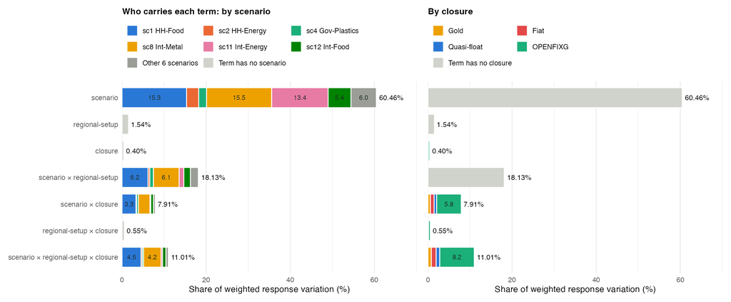

Each bar is one term's share of the weighted response variation (total at the bar end). The segments split it by the runs that carry it: left, by scenario (the six largest contributors named, the other six pooled); right, by closure. A grey bar is a term that does not contain that factor, so splitting it would give equal parts by construction. Segment labels are percentage points of the total variation, shown where at least 3.

The 96 runs form a complete factorial design: every one of the twelve scenarios is run under both regional setups (EU/RoW and North/South) and all four closures, one run per cell. The variation of the responses (74 standardised response coordinates, the six outcome blocks weighted equally) therefore splits exactly into seven non-overlapping parts, shown above. The scenario alone accounts for 60.5%: what the intervention is decides most of what happens. On their own, the regional setup (1.5%), the closure (0.4%) and the two together (0.6%) hardly matter: averaged over all twelve interventions, neither how the world is partitioned nor how the external account is closed moves the responses much. The rest is interaction with the scenario: scenario × regional-setup 18.1%, scenario × closure 7.9% and scenario × regional-setup × closure 11.0%. Together that is 37.0% of the variation, 29.1% in the two terms that involve the regional setup. This variation exists only in combination: a study run on one partition of the world and one closure would see the scenario effect and miss more than a third of what the interventions do.

**Scenario × regional-setup** measures, for each scenario, how far the change in its response between EU/RoW and North/South departs from the change the regional setup makes on average across all scenarios. Because the regional setup alone explains only 1.5%, the 18.1% here means that re-partitioning the world changes some interventions a great deal and others hardly at all. The term is concentrated: sc1 HH-Food carries 34.1% of it, sc8 Int-Metal 33.7% and sc12 Int-Food 8.7%, while 6 of the twelve scenarios carry under 3% each. The mechanism is the input–output structure on each side of the border. A substitution moves demand between a primary and a secondary sector; the North/South partition places different industries and trading partners on each side of the border than EU/RoW does, so the same substitution meets different cross-border Leontief coefficients (the l<sub>12</sub> against l<sub>11</sub> comparison of the analytical ΔM formulas) and lands its demand, materials and employment in a different region. That is why the term is largest in the ecological block (24.0% of that block's variation) and in labour and distribution (21.1%): where the material and the employment content of a substitution is booked depends on the partition.

**Scenario × regional-setup × closure** measures whether the closure's effect on a scenario is itself different in the two regional setups, after everything the three pairwise combinations explain has been removed. In a deterministic model with one run per cell this is not noise or a residual; it is genuine non-additivity. It is concentrated in one closure and two scenarios: OPENFIXG cells carry 74.5% of the term, and sc1 HH-Food and sc8 Int-Metal together 79.1%. OPENFIXG makes the intervening region's real government spending the residual of its budget constraint, so the external imbalance that a shock opens is absorbed by fiscal policy, and the size and sign of that imbalance depend on the scenario and the partition together. In value added (mean over t = 79..100, % deviation from the arm's own baseline): sc1 HH-Food under the gold closure is production leakage in both setups, EU/RoW Z1 -0.044%, Z2 +0.032% (PL) and North/South Z1 -0.068%, Z2 +0.036% (PL); under OPENFIXG it becomes Z1 -0.113%, Z2 +0.003% (CC) in EU/RoW but Z1 +0.006%, Z2 +0.186% (DE) in North/South. sc8 Int-Metal under OPENFIXG stays Z1 +0.094%, Z2 -0.003% (CD) in EU/RoW, but turns to Z1 -0.012%, Z2 -0.175% (DC) in North/South. By block, the three-way term is largest in the fiscal (16.9%), finance and wealth (14.3%) and labour and distribution (13.8%) blocks and smallest in the ecological block (3.2%): the closure redistributes the macro-financial adjustment between the regions, while the ecological footprint is set mostly by the scenario and the regional setup. These are descriptive shares; with no residual degrees of freedom there are no significance tests.

## Hierarchical response clustering

Leaves Regional setup Distance Groups 12Highlight

Select a named leaf, regime tile or qualifier to inspect it. Highlighting preserves the full hierarchy.

### Reading this tree

#### Cut by cut

Each cut is a merge of the tree read from the root down: cut j takes the tree from j to j + 1 groups. Cuts that the current “Groups” setting has made are in full colour, deeper ones are greyed. Regime counts are the value-added rule’s tiles on each side (one per setup × closure configuration). “What separates them” lists the four responses whose standardised means differ most between the two sides, with each side’s median raw response averaged over t = 79..100 (one cycle) over its scenarios and configurations.

**Method**

**Tree.** Rows are the leaves (scenarios, or individual observations); columns are their responses averaged over t = 79..100, each standardised over the rows and divided by the square root of the number of columns in its outcome block, so the six blocks (real activity, fiscal, external, labour and distribution, finance and wealth, ecological) weigh equally. The tree is agglomerative: it starts with every leaf alone and, at each step, merges the two groups whose union increases the total within-group sum of squared distances the least (Ward’s criterion, in the “D2” form that works on Euclidean distances). The merge height is that increase on the distance scale, so a long vertical gap before a merge means the two groups it joins are far apart. Cutting the tree at a height gives the groups; “cut j” in the reading above is the j-th merge counted from the root. The per-cut drivers are descriptive: per zone × variable, the mean over its columns of the difference between the two sides’ standardised means (R/scenarios/tree_split_drivers.R); they name what differs most, and are not the tree’s own weighting.

Branch geometry uses Ward D2 on the standardised, equally block-weighted responses. Coloured circles identify statistical groups at the chosen cut. Regime tiles use the separate value-added rule; hover or focus them for signed responses.

**Qualifiers.** Each leaf uses the same regime-specific tercile thresholds as the Groups descriptions: the size of Z2’s value-added response for CD and PL, and the smaller absolute response across regions for DC. CC is weak by definition; DE has no tercile because it has only two observations. The Groups description grades a group median, so its qualifier need not match every leaf in a mixed group. In profile view, W, M and S mean weak, moderate and strong.

## Groups

Groups (k) 12

[output not shown]

## Principal component analysis

Representation Regional setup Outlined Ward groups (k = 12) Group names Shaded regime ovalsFind

The cluster cut is fixed at **k = 12**: the same twelve groups, the same numbering (G1 = the group of the top leaf of the pooled tree) and the same names as the Groups tab, which cuts the same pooled Ward tree of the 96 observations. Each outlined oval encloses one group's observations in this two-dimensional projection and carries its name on short lines; it is not a confidence region, and ovals can overlap because the clustering uses all the response coordinates, not just two. Point colour is the scenario, point shape the closure (● gold, ■ fiat, ▲ quasi-float, ◆ OPENFIXG), and a dashed ring marks North/South; an unringed point is EU/RoW. Hover a point for its full label, or hover a scenario in the legend to pick out its points. Twelve colours cannot all be told apart by colour alone, so the legend highlight, the popup and Find are the reliable way to identify a point. With one setup selected the PCA is recomputed on that setup's 48 observations (columns re-standardised), so the axes are not comparable across setups; the groups stay those of the pooled tree, restricted to that setup. Shaded borderless ovals show the fully named value-added regimes. The k = 12 cut is a cut of observations, so the 12 scenario profiles carry no group ovals.

Hover or focus a point for its scenario, closure, setup, group and regime.

## Regional response quadrants

Where each scenario falls when the question is simply: does the intervening region Z1 rise or fall, and does its partner Z2 rise or fall? Choose a setup, a closure and an outcome block; the colour is always the value-added regime, so the grid shows whether a regime keeps its pattern in other outcomes. Responses are the stored responses averaged over t = 79..100; no simulation is rerun.

Regional setup Closure Outcome block Variable View

Hover or focus a scenario for its two responses.

## Response heatmap

Regional setup Closure Rows Row tree Columns Block Colour

Hover or focus a cell for its value, unit and basis.

**How to read it.** Each cell is one response averaged over t = 79..100 (one cycle): rows are scenarios (or the median over a family's members), columns are a variable in one region (Z1 = the region whose intervention is switched on, EU or North; Z2 = RoW or South). Green is an increase and red a decrease. Units differ by variable (percentage change from the arm's own baseline; level difference as a share of own baseline value added for the deficit, current account and trade balance; point difference for shares and debt/GDP), so colour is relative within each column. The default colour scale divides each cell by the largest absolute response in its column among the rows shown (the scenario rows, or the 3 families), so a pale cell is small *relative to other scenarios*, and white means zero. The z-score option shows the standardised values the trees are built on; there, white means “average across scenarios”, not “no response”. The row dendrogram is Ward D2 on the block-weighted standardised matrix shown (same construction as the Dendrograms tab, but on one closure or the median over the three monetary closures). Several columns are exact duplicates by model construction: employment, female employment, the wage bill and worker disposable income move together because the money wage is anchored; the wage share is minus the profit share; Z1's real exports are Z2's real imports. Real government spending is exogenous except under OPENFIXG, so its column is blank elsewhere.

**Note.** Grid: the 96 high-finance credit runs (D-58/D-60): twelve presentation scenarios × two regional setups (EU/RoW, North/South) × four external closures (gold, fiat, quasi-float, OPENFIXG), each response averaged over t = 79..100 (one cycle) against its own arm's unshocked baseline. Analysis tag `20261012_c79`; no simulation is run by this page.